# Risk Factor Analysis

## Outcome Variable

**Outcome Variable:** ever_stunted

## Predictor Variables

**Intervention Variable:** hhwealth_quart

**Adjustment Set:**

- arm
- sex
- W_mage
- meducyrs
- feducyrs
- W_gagebrth
- W_birthwt
- W_birthlen
- W_nchldlt5
- W_parity
- delta_sex
- delta_W_mage
- delta_meducyrs
- delta_feducyrs
- delta_W_gagebrth
- delta_W_birthwt
- delta_W_birthlen
- delta_W_nchldlt5
- delta_W_parity

## Stratifying Variables

The analysis was stratified on these variable(s):

- agecat
- studyid
- country

## Data Summary

| agecat | studyid | country | hhwealth_quart | ever_stunted | n_cell | n |
| --- | --- | --- | --- | --- | --- | --- |
| 0-24 months | CMC-V-BCS-2002 | INDIA | Wealth Q4 | 0 | 6 | 373 |
| 0-24 months | CMC-V-BCS-2002 | INDIA | Wealth Q4 | 1 | 90 | 373 |
| 0-24 months | CMC-V-BCS-2002 | INDIA | Wealth Q1 | 0 | 6 | 373 |
| 0-24 months | CMC-V-BCS-2002 | INDIA | Wealth Q1 | 1 | 85 | 373 |
| 0-24 months | CMC-V-BCS-2002 | INDIA | Wealth Q2 | 0 | 8 | 373 |
| 0-24 months | CMC-V-BCS-2002 | INDIA | Wealth Q2 | 1 | 87 | 373 |
| 0-24 months | CMC-V-BCS-2002 | INDIA | Wealth Q3 | 0 | 8 | 373 |
| 0-24 months | CMC-V-BCS-2002 | INDIA | Wealth Q3 | 1 | 83 | 373 |
| 0-24 months | COHORTS | GUATEMALA | Wealth Q4 | 0 | 130 | 1278 |
| 0-24 months | COHORTS | GUATEMALA | Wealth Q4 | 1 | 355 | 1278 |
| 0-24 months | COHORTS | GUATEMALA | Wealth Q1 | 0 | 47 | 1278 |
| 0-24 months | COHORTS | GUATEMALA | Wealth Q1 | 1 | 198 | 1278 |
| 0-24 months | COHORTS | GUATEMALA | Wealth Q2 | 0 | 45 | 1278 |
| 0-24 months | COHORTS | GUATEMALA | Wealth Q2 | 1 | 215 | 1278 |
| 0-24 months | COHORTS | GUATEMALA | Wealth Q3 | 0 | 70 | 1278 |
| 0-24 months | COHORTS | GUATEMALA | Wealth Q3 | 1 | 218 | 1278 |
| 0-24 months | COHORTS | PHILIPPINES | Wealth Q4 | 0 | 370 | 3057 |
| 0-24 months | COHORTS | PHILIPPINES | Wealth Q4 | 1 | 473 | 3057 |
| 0-24 months | COHORTS | PHILIPPINES | Wealth Q1 | 0 | 195 | 3057 |
| 0-24 months | COHORTS | PHILIPPINES | Wealth Q1 | 1 | 492 | 3057 |
| 0-24 months | COHORTS | PHILIPPINES | Wealth Q2 | 0 | 157 | 3057 |
| 0-24 months | COHORTS | PHILIPPINES | Wealth Q2 | 1 | 385 | 3057 |
| 0-24 months | COHORTS | PHILIPPINES | Wealth Q3 | 0 | 236 | 3057 |
| 0-24 months | COHORTS | PHILIPPINES | Wealth Q3 | 1 | 749 | 3057 |
| 0-24 months | CONTENT | PERU | Wealth Q4 | 0 | 44 | 215 |
| 0-24 months | CONTENT | PERU | Wealth Q4 | 1 | 8 | 215 |
| 0-24 months | CONTENT | PERU | Wealth Q1 | 0 | 42 | 215 |
| 0-24 months | CONTENT | PERU | Wealth Q1 | 1 | 17 | 215 |
| 0-24 months | CONTENT | PERU | Wealth Q2 | 0 | 35 | 215 |
| 0-24 months | CONTENT | PERU | Wealth Q2 | 1 | 17 | 215 |

[output cut: 402 more lines]

The following strata were considered:

- agecat: 0-24 months, studyid: CMC-V-BCS-2002, country: INDIA
- agecat: 0-24 months, studyid: COHORTS, country: GUATEMALA
- agecat: 0-24 months, studyid: COHORTS, country: PHILIPPINES
- agecat: 0-24 months, studyid: CONTENT, country: PERU
- agecat: 0-24 months, studyid: GMS-Nepal, country: NEPAL
- agecat: 0-24 months, studyid: IRC, country: INDIA
- agecat: 0-24 months, studyid: JiVitA-3, country: BANGLADESH
- agecat: 0-24 months, studyid: JiVitA-4, country: BANGLADESH
- agecat: 0-24 months, studyid: LCNI-5, country: MALAWI
- agecat: 0-24 months, studyid: MAL-ED, country: BANGLADESH
- agecat: 0-24 months, studyid: MAL-ED, country: BRAZIL
- agecat: 0-24 months, studyid: MAL-ED, country: INDIA
- agecat: 0-24 months, studyid: MAL-ED, country: NEPAL
- agecat: 0-24 months, studyid: MAL-ED, country: PERU
- agecat: 0-24 months, studyid: MAL-ED, country: SOUTH AFRICA
- agecat: 0-24 months, studyid: MAL-ED, country: TANZANIA, UNITED REPUBLIC OF
- agecat: 0-24 months, studyid: PROVIDE, country: BANGLADESH
- agecat: 0-24 months, studyid: TanzaniaChild2, country: TANZANIA, UNITED REPUBLIC OF
- agecat: 0-6 months, studyid: CMC-V-BCS-2002, country: INDIA
- agecat: 0-6 months, studyid: COHORTS, country: GUATEMALA
- agecat: 0-6 months, studyid: COHORTS, country: PHILIPPINES
- agecat: 0-6 months, studyid: CONTENT, country: PERU
- agecat: 0-6 months, studyid: GMS-Nepal, country: NEPAL
- agecat: 0-6 months, studyid: IRC, country: INDIA
- agecat: 0-6 months, studyid: JiVitA-3, country: BANGLADESH
- agecat: 0-6 months, studyid: JiVitA-4, country: BANGLADESH
- agecat: 0-6 months, studyid: LCNI-5, country: MALAWI
- agecat: 0-6 months, studyid: MAL-ED, country: BANGLADESH
- agecat: 0-6 months, studyid: MAL-ED, country: BRAZIL
- agecat: 0-6 months, studyid: MAL-ED, country: INDIA
- agecat: 0-6 months, studyid: MAL-ED, country: NEPAL
- agecat: 0-6 months, studyid: MAL-ED, country: PERU
- agecat: 0-6 months, studyid: MAL-ED, country: SOUTH AFRICA
- agecat: 0-6 months, studyid: MAL-ED, country: TANZANIA, UNITED REPUBLIC OF
- agecat: 0-6 months, studyid: PROVIDE, country: BANGLADESH
- agecat: 0-6 months, studyid: TanzaniaChild2, country: TANZANIA, UNITED REPUBLIC OF
- agecat: 6-24 months, studyid: CMC-V-BCS-2002, country: INDIA
- agecat: 6-24 months, studyid: COHORTS, country: GUATEMALA
- agecat: 6-24 months, studyid: COHORTS, country: PHILIPPINES
- agecat: 6-24 months, studyid: CONTENT, country: PERU
- agecat: 6-24 months, studyid: GMS-Nepal, country: NEPAL
- agecat: 6-24 months, studyid: IRC, country: INDIA
- agecat: 6-24 months, studyid: JiVitA-3, country: BANGLADESH
- agecat: 6-24 months, studyid: JiVitA-4, country: BANGLADESH
- agecat: 6-24 months, studyid: LCNI-5, country: MALAWI
- agecat: 6-24 months, studyid: MAL-ED, country: BANGLADESH
- agecat: 6-24 months, studyid: MAL-ED, country: BRAZIL
- agecat: 6-24 months, studyid: MAL-ED, country: INDIA
- agecat: 6-24 months, studyid: MAL-ED, country: NEPAL
- agecat: 6-24 months, studyid: MAL-ED, country: PERU
- agecat: 6-24 months, studyid: MAL-ED, country: SOUTH AFRICA
- agecat: 6-24 months, studyid: MAL-ED, country: TANZANIA, UNITED REPUBLIC OF
- agecat: 6-24 months, studyid: PROVIDE, country: BANGLADESH
- agecat: 6-24 months, studyid: TanzaniaChild2, country: TANZANIA, UNITED REPUBLIC OF

### Dropped Strata

Some strata were dropped due to rare outcomes:

- agecat: 0-24 months, studyid: MAL-ED, country: TANZANIA, UNITED REPUBLIC OF
- agecat: 0-6 months, studyid: CONTENT, country: PERU
- agecat: 6-24 months, studyid: CONTENT, country: PERU
- agecat: 6-24 months, studyid: MAL-ED, country: BRAZIL
- agecat: 6-24 months, studyid: MAL-ED, country: TANZANIA, UNITED REPUBLIC OF

## Methods Detail

We’re interested in the causal parameters $E[Y_a]$ for all values of $a \in \mathcal{A}$. These parameters represent the mean outcome if, possibly contrary to fact, we intervened to set all units to have $A=a$. Under the randomization and positivity assumptions, these are identified by the statistical parameters $\psi_a=E_W[E_{Y|A,W}(Y|A=a,W)]$. In addition, we’re interested in the mean of $Y$, $E[Y]$ under no intervention (the observed mean). We will estimate these parameters by using SuperLearner to fit the relevant likelihood factors – $E_{Y|A,W}(Y|A=a,W)$ and $p(A=a|W)$, and then updating our likelihood fit using a joint TMLE.

For unadjusted analyses ($W=\{\}$), initial likelihoods were estimated using Lrnr_glm to estimate the simple $E(Y|A)$ and Lrnr_mean to estimate $p(A)$. For adjusted analyses, a small library containing Lrnr_glmnet, Lrnr_xgboost, and Lrnr_mean was used.

Having estimated these parameters, we will then use the delta method to estimate relative risks and attributable risks relative to a prespecified baseline level of $A$.

# Results Detail

## Results Plots

[figure not shown]

[figure not shown]

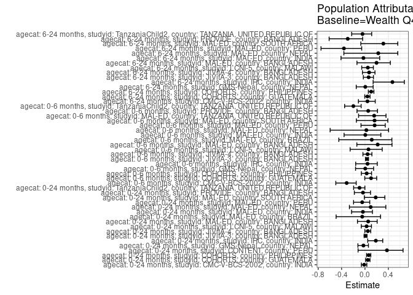

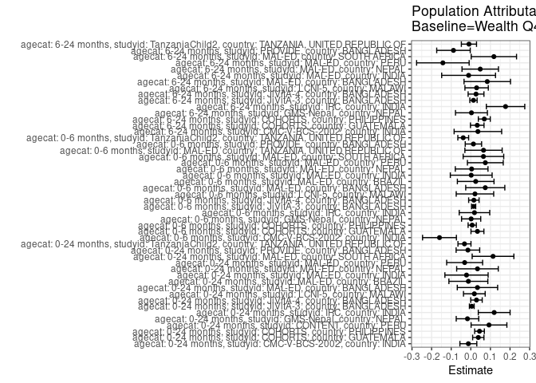

## Results Table

### Parameter: TSM

| agecat | studyid | country | intervention_level | baseline_level | estimate | ci_lower | ci_upper |
| --- | --- | --- | --- | --- | --- | --- | --- |
| 0-24 months | CMC-V-BCS-2002 | INDIA | Wealth Q4 | NA | 0.9375000 | 0.8890135 | 0.9859865 |
| 0-24 months | CMC-V-BCS-2002 | INDIA | Wealth Q1 | NA | 0.9340659 | 0.8830091 | 0.9851228 |
| 0-24 months | CMC-V-BCS-2002 | INDIA | Wealth Q2 | NA | 0.9157895 | 0.8598717 | 0.9717073 |
| 0-24 months | CMC-V-BCS-2002 | INDIA | Wealth Q3 | NA | 0.9120879 | 0.8538303 | 0.9703456 |
| 0-24 months | COHORTS | GUATEMALA | Wealth Q4 | NA | 0.7333611 | 0.6948127 | 0.7719095 |
| 0-24 months | COHORTS | GUATEMALA | Wealth Q1 | NA | 0.7901894 | 0.7419478 | 0.8384310 |
| 0-24 months | COHORTS | GUATEMALA | Wealth Q2 | NA | 0.8291288 | 0.7834194 | 0.8748383 |
| 0-24 months | COHORTS | GUATEMALA | Wealth Q3 | NA | 0.7671513 | 0.7204346 | 0.8138680 |
| 0-24 months | COHORTS | PHILIPPINES | Wealth Q4 | NA | 0.6422650 | 0.6121023 | 0.6724278 |
| 0-24 months | COHORTS | PHILIPPINES | Wealth Q1 | NA | 0.6893668 | 0.6552429 | 0.7234907 |
| 0-24 months | COHORTS | PHILIPPINES | Wealth Q2 | NA | 0.6794216 | 0.6420826 | 0.7167606 |
| 0-24 months | COHORTS | PHILIPPINES | Wealth Q3 | NA | 0.7328946 | 0.7060062 | 0.7597830 |
| 0-24 months | CONTENT | PERU | Wealth Q4 | NA | 0.1538462 | 0.0555522 | 0.2521401 |
| 0-24 months | CONTENT | PERU | Wealth Q1 | NA | 0.2881356 | 0.1723028 | 0.4039684 |
| 0-24 months | CONTENT | PERU | Wealth Q2 | NA | 0.3269231 | 0.1991281 | 0.4547181 |
| 0-24 months | CONTENT | PERU | Wealth Q3 | NA | 0.2115385 | 0.1002773 | 0.3227996 |
| 0-24 months | GMS-Nepal | NEPAL | Wealth Q4 | NA | 0.6560259 | 0.5880385 | 0.7240133 |
| 0-24 months | GMS-Nepal | NEPAL | Wealth Q1 | NA | 0.6056763 | 0.5392861 | 0.6720664 |
| 0-24 months | GMS-Nepal | NEPAL | Wealth Q2 | NA | 0.6951339 | 0.6315399 | 0.7587278 |
| 0-24 months | GMS-Nepal | NEPAL | Wealth Q3 | NA | 0.5970876 | 0.5285676 | 0.6656077 |
| 0-24 months | IRC | INDIA | Wealth Q4 | NA | 0.5222506 | 0.4269409 | 0.6175604 |
| 0-24 months | IRC | INDIA | Wealth Q1 | NA | 0.6897830 | 0.6024553 | 0.7771106 |
| 0-24 months | IRC | INDIA | Wealth Q2 | NA | 0.6817961 | 0.5932913 | 0.7703008 |
| 0-24 months | IRC | INDIA | Wealth Q3 | NA | 0.6751821 | 0.5837996 | 0.7665645 |
| 0-24 months | JiVitA-3 | BANGLADESH | Wealth Q4 | NA | 0.4904500 | 0.4758680 | 0.5050320 |
| 0-24 months | JiVitA-3 | BANGLADESH | Wealth Q1 | NA | 0.4999511 | 0.4847013 | 0.5152009 |
| 0-24 months | JiVitA-3 | BANGLADESH | Wealth Q2 | NA | 0.5110941 | 0.4986842 | 0.5235040 |
| 0-24 months | JiVitA-3 | BANGLADESH | Wealth Q3 | NA | 0.4932872 | 0.4811481 | 0.5054263 |
| 0-24 months | JiVitA-4 | BANGLADESH | Wealth Q4 | NA | 0.5529577 | 0.5198522 | 0.5860632 |
| 0-24 months | JiVitA-4 | BANGLADESH | Wealth Q1 | NA | 0.6023091 | 0.5718601 | 0.6327582 |

[output cut: 166 more lines]

### Parameter: E(Y)

| agecat | studyid | country | intervention_level | baseline_level | estimate | ci_lower | ci_upper |
| --- | --- | --- | --- | --- | --- | --- | --- |
| 0-24 months | CMC-V-BCS-2002 | INDIA | NA | NA | 0.9249330 | 0.8981563 | 0.9517096 |
| 0-24 months | COHORTS | GUATEMALA | NA | NA | 0.7715180 | 0.7484902 | 0.7945458 |
| 0-24 months | COHORTS | PHILIPPINES | NA | NA | 0.6866209 | 0.6701747 | 0.7030670 |
| 0-24 months | CONTENT | PERU | NA | NA | 0.2465116 | 0.1887688 | 0.3042545 |
| 0-24 months | GMS-Nepal | NEPAL | NA | NA | 0.6389685 | 0.6033115 | 0.6746254 |
| 0-24 months | IRC | INDIA | NA | NA | 0.6414634 | 0.5949863 | 0.6879405 |
| 0-24 months | JiVitA-3 | BANGLADESH | NA | NA | 0.4954233 | 0.4875870 | 0.5032596 |
| 0-24 months | JiVitA-4 | BANGLADESH | NA | NA | 0.5818282 | 0.5658219 | 0.5978346 |
| 0-24 months | LCNI-5 | MALAWI | NA | NA | 0.6376989 | 0.6047193 | 0.6706785 |
| 0-24 months | MAL-ED | BANGLADESH | NA | NA | 0.6157025 | 0.5542897 | 0.6771153 |
| 0-24 months | MAL-ED | BRAZIL | NA | NA | 0.2666667 | 0.2067138 | 0.3266195 |
| 0-24 months | MAL-ED | INDIA | NA | NA | 0.6212766 | 0.5591262 | 0.6834270 |
| 0-24 months | MAL-ED | NEPAL | NA | NA | 0.3474576 | 0.2865784 | 0.4083369 |
| 0-24 months | MAL-ED | PERU | NA | NA | 0.6654412 | 0.6092647 | 0.7216177 |
| 0-24 months | MAL-ED | SOUTH AFRICA | NA | NA | 0.6186770 | 0.5591785 | 0.6781756 |
| 0-24 months | PROVIDE | BANGLADESH | NA | NA | 0.4357143 | 0.3989556 | 0.4724730 |
| 0-24 months | TanzaniaChild2 | TANZANIA, UNITED REPUBLIC OF | NA | NA | 0.3468960 | 0.3277853 | 0.3660067 |
| 0-6 months | CMC-V-BCS-2002 | INDIA | NA | NA | 0.5108696 | 0.4597270 | 0.5620121 |
| 0-6 months | COHORTS | GUATEMALA | NA | NA | 0.3240116 | 0.2955133 | 0.3525098 |
| 0-6 months | COHORTS | PHILIPPINES | NA | NA | 0.2391233 | 0.2240003 | 0.2542464 |
| 0-6 months | GMS-Nepal | NEPAL | NA | NA | 0.3180516 | 0.2834770 | 0.3526261 |
| 0-6 months | IRC | INDIA | NA | NA | 0.4243902 | 0.3764905 | 0.4722900 |
| 0-6 months | JiVitA-3 | BANGLADESH | NA | NA | 0.4130891 | 0.4056400 | 0.4205383 |
| 0-6 months | JiVitA-4 | BANGLADESH | NA | NA | 0.3474692 | 0.3322601 | 0.3626783 |
| 0-6 months | LCNI-5 | MALAWI | NA | NA | 0.3531599 | 0.2959376 | 0.4103821 |
| 0-6 months | MAL-ED | BANGLADESH | NA | NA | 0.3388430 | 0.2790857 | 0.3986003 |
| 0-6 months | MAL-ED | BRAZIL | NA | NA | 0.2142857 | 0.1586564 | 0.2699151 |
| 0-6 months | MAL-ED | INDIA | NA | NA | 0.3446809 | 0.2837868 | 0.4055749 |
| 0-6 months | MAL-ED | NEPAL | NA | NA | 0.1737288 | 0.1252880 | 0.2221696 |
| 0-6 months | MAL-ED | PERU | NA | NA | 0.4485294 | 0.3893160 | 0.5077428 |
| 0-6 months | MAL-ED | SOUTH AFRICA | NA | NA | 0.3929961 | 0.3331663 | 0.4528260 |
| 0-6 months | MAL-ED | TANZANIA, UNITED REPUBLIC OF | NA | NA | 0.4120000 | 0.3508656 | 0.4731344 |
| 0-6 months | PROVIDE | BANGLADESH | NA | NA | 0.2400000 | 0.2083392 | 0.2716608 |
| 0-6 months | TanzaniaChild2 | TANZANIA, UNITED REPUBLIC OF | NA | NA | 0.1950503 | 0.1791413 | 0.2109594 |
| 6-24 months | CMC-V-BCS-2002 | INDIA | NA | NA | 0.8486486 | 0.7968646 | 0.9004327 |
| 6-24 months | COHORTS | GUATEMALA | NA | NA | 0.7665094 | 0.7380190 | 0.7949999 |
| 6-24 months | COHORTS | PHILIPPINES | NA | NA | 0.6449788 | 0.6246093 | 0.6653483 |
| 6-24 months | GMS-Nepal | NEPAL | NA | NA | 0.5642317 | 0.5153938 | 0.6130696 |
| 6-24 months | IRC | INDIA | NA | NA | 0.3771186 | 0.3151523 | 0.4390850 |
| 6-24 months | JiVitA-3 | BANGLADESH | NA | NA | 0.2161518 | 0.2067762 | 0.2255274 |
| 6-24 months | JiVitA-4 | BANGLADESH | NA | NA | 0.3784303 | 0.3598372 | 0.3970234 |
| 6-24 months | LCNI-5 | MALAWI | NA | NA | 0.6000000 | 0.5639396 | 0.6360604 |
| 6-24 months | MAL-ED | BANGLADESH | NA | NA | 0.4240506 | 0.3467471 | 0.5013542 |
| 6-24 months | MAL-ED | INDIA | NA | NA | 0.4220779 | 0.3438191 | 0.5003367 |
| 6-24 months | MAL-ED | NEPAL | NA | NA | 0.2113402 | 0.1537425 | 0.2689379 |
| 6-24 months | MAL-ED | PERU | NA | NA | 0.3959732 | 0.3171819 | 0.4747644 |
| 6-24 months | MAL-ED | SOUTH AFRICA | NA | NA | 0.3741935 | 0.2977649 | 0.4506221 |
| 6-24 months | PROVIDE | BANGLADESH | NA | NA | 0.3004386 | 0.2583143 | 0.3425629 |
| 6-24 months | TanzaniaChild2 | TANZANIA, UNITED REPUBLIC OF | NA | NA | 0.2268170 | 0.2062654 | 0.2473687 |

### Parameter: RR

| agecat | studyid | country | intervention_level | baseline_level | estimate | ci_lower | ci_upper |
| --- | --- | --- | --- | --- | --- | --- | --- |
| 0-24 months | CMC-V-BCS-2002 | INDIA | Wealth Q4 | Wealth Q4 | 1.0000000 | 1.0000000 | 1.0000000 |
| 0-24 months | CMC-V-BCS-2002 | INDIA | Wealth Q1 | Wealth Q4 | 0.9963370 | 0.9241135 | 1.0742051 |
| 0-24 months | CMC-V-BCS-2002 | INDIA | Wealth Q2 | Wealth Q4 | 0.9768421 | 0.9017212 | 1.0582212 |
| 0-24 months | CMC-V-BCS-2002 | INDIA | Wealth Q3 | Wealth Q4 | 0.9728938 | 0.8961328 | 1.0562300 |
| 0-24 months | COHORTS | GUATEMALA | Wealth Q4 | Wealth Q4 | 1.0000000 | 1.0000000 | 1.0000000 |
| 0-24 months | COHORTS | GUATEMALA | Wealth Q1 | Wealth Q4 | 1.0774902 | 0.9952743 | 1.1664977 |
| 0-24 months | COHORTS | GUATEMALA | Wealth Q2 | Wealth Q4 | 1.1305874 | 1.0482695 | 1.2193695 |
| 0-24 months | COHORTS | GUATEMALA | Wealth Q3 | Wealth Q4 | 1.0460758 | 0.9667632 | 1.1318952 |
| 0-24 months | COHORTS | PHILIPPINES | Wealth Q4 | Wealth Q4 | 1.0000000 | 1.0000000 | 1.0000000 |
| 0-24 months | COHORTS | PHILIPPINES | Wealth Q1 | Wealth Q4 | 1.0733370 | 1.0039442 | 1.1475262 |
| 0-24 months | COHORTS | PHILIPPINES | Wealth Q2 | Wealth Q4 | 1.0578525 | 0.9858634 | 1.1350983 |
| 0-24 months | COHORTS | PHILIPPINES | Wealth Q3 | Wealth Q4 | 1.1411093 | 1.0768162 | 1.2092411 |
| 0-24 months | CONTENT | PERU | Wealth Q4 | Wealth Q4 | 1.0000000 | 1.0000000 | 1.0000000 |
| 0-24 months | CONTENT | PERU | Wealth Q1 | Wealth Q4 | 1.8728814 | 0.8803953 | 3.9842154 |
| 0-24 months | CONTENT | PERU | Wealth Q2 | Wealth Q4 | 2.1250000 | 1.0047762 | 4.4941600 |
| 0-24 months | CONTENT | PERU | Wealth Q3 | Wealth Q4 | 1.3750000 | 0.6010371 | 3.1456043 |
| 0-24 months | GMS-Nepal | NEPAL | Wealth Q4 | Wealth Q4 | 1.0000000 | 1.0000000 | 1.0000000 |
| 0-24 months | GMS-Nepal | NEPAL | Wealth Q1 | Wealth Q4 | 0.9232506 | 0.7968565 | 1.0696927 |
| 0-24 months | GMS-Nepal | NEPAL | Wealth Q2 | Wealth Q4 | 1.0596135 | 0.9261892 | 1.2122585 |
| 0-24 months | GMS-Nepal | NEPAL | Wealth Q3 | Wealth Q4 | 0.9101587 | 0.7823090 | 1.0589023 |
| 0-24 months | IRC | INDIA | Wealth Q4 | Wealth Q4 | 1.0000000 | 1.0000000 | 1.0000000 |
| 0-24 months | IRC | INDIA | Wealth Q1 | Wealth Q4 | 1.3207891 | 1.0604249 | 1.6450801 |
| 0-24 months | IRC | INDIA | Wealth Q2 | Wealth Q4 | 1.3054959 | 1.0460409 | 1.6293048 |
| 0-24 months | IRC | INDIA | Wealth Q3 | Wealth Q4 | 1.2928315 | 1.0316797 | 1.6200893 |
| 0-24 months | JiVitA-3 | BANGLADESH | Wealth Q4 | Wealth Q4 | 1.0000000 | 1.0000000 | 1.0000000 |
| 0-24 months | JiVitA-3 | BANGLADESH | Wealth Q1 | Wealth Q4 | 1.0193723 | 0.9809397 | 1.0593105 |
| 0-24 months | JiVitA-3 | BANGLADESH | Wealth Q2 | Wealth Q4 | 1.0420923 | 1.0074569 | 1.0779183 |
| 0-24 months | JiVitA-3 | BANGLADESH | Wealth Q3 | Wealth Q4 | 1.0057849 | 0.9719686 | 1.0407777 |
| 0-24 months | JiVitA-4 | BANGLADESH | Wealth Q4 | Wealth Q4 | 1.0000000 | 1.0000000 | 1.0000000 |
| 0-24 months | JiVitA-4 | BANGLADESH | Wealth Q1 | Wealth Q4 | 1.0892498 | 1.0100361 | 1.1746760 |

[output cut: 166 more lines]

### Parameter: PAR

| agecat | studyid | country | intervention_level | baseline_level | estimate | ci_lower | ci_upper |
| --- | --- | --- | --- | --- | --- | --- | --- |
| 0-24 months | CMC-V-BCS-2002 | INDIA | Wealth Q4 | NA | -0.0125670 | -0.0556692 | 0.0305351 |
| 0-24 months | COHORTS | GUATEMALA | Wealth Q4 | NA | 0.0381569 | 0.0093650 | 0.0669488 |
| 0-24 months | COHORTS | PHILIPPINES | Wealth Q4 | NA | 0.0443559 | 0.0196732 | 0.0690385 |
| 0-24 months | CONTENT | PERU | Wealth Q4 | NA | 0.0926655 | 0.0014385 | 0.1838925 |
| 0-24 months | GMS-Nepal | NEPAL | Wealth Q4 | NA | -0.0170574 | -0.0744590 | 0.0403443 |
| 0-24 months | IRC | INDIA | Wealth Q4 | NA | 0.1192128 | 0.0380778 | 0.2003477 |
| 0-24 months | JiVitA-3 | BANGLADESH | Wealth Q4 | NA | 0.0049733 | -0.0072161 | 0.0171627 |
| 0-24 months | JiVitA-4 | BANGLADESH | Wealth Q4 | NA | 0.0288705 | -0.0003743 | 0.0581153 |
| 0-24 months | LCNI-5 | MALAWI | Wealth Q4 | NA | 0.0179783 | -0.0373318 | 0.0732883 |
| 0-24 months | MAL-ED | BANGLADESH | Wealth Q4 | NA | 0.0338889 | -0.0690367 | 0.1368146 |
| 0-24 months | MAL-ED | BRAZIL | Wealth Q4 | NA | -0.0124841 | -0.1117401 | 0.0867719 |
| 0-24 months | MAL-ED | INDIA | Wealth Q4 | NA | -0.0219714 | -0.1322105 | 0.0882677 |
| 0-24 months | MAL-ED | NEPAL | Wealth Q4 | NA | 0.0339345 | -0.0721573 | 0.1400262 |
| 0-24 months | MAL-ED | PERU | Wealth Q4 | NA | -0.0314639 | -0.1231540 | 0.0602261 |
| 0-24 months | MAL-ED | SOUTH AFRICA | Wealth Q4 | NA | 0.1133583 | 0.0070046 | 0.2197121 |
| 0-24 months | PROVIDE | BANGLADESH | Wealth Q4 | NA | -0.0148844 | -0.0749641 | 0.0451953 |
| 0-24 months | TanzaniaChild2 | TANZANIA, UNITED REPUBLIC OF | Wealth Q4 | NA | -0.0323486 | -0.0655740 | 0.0008767 |
| 0-6 months | CMC-V-BCS-2002 | INDIA | Wealth Q4 | NA | -0.1597624 | -0.2460786 | -0.0734461 |
| 0-6 months | COHORTS | GUATEMALA | Wealth Q4 | NA | 0.0337850 | 0.0008619 | 0.0667081 |
| 0-6 months | COHORTS | PHILIPPINES | Wealth Q4 | NA | 0.0070515 | -0.0137936 | 0.0278965 |
| 0-6 months | GMS-Nepal | NEPAL | Wealth Q4 | NA | 0.0017014 | -0.0471594 | 0.0505622 |
| 0-6 months | IRC | INDIA | Wealth Q4 | NA | 0.0185884 | -0.0592639 | 0.0964407 |
| 0-6 months | JiVitA-3 | BANGLADESH | Wealth Q4 | NA | 0.0145311 | 0.0040871 | 0.0249752 |
| 0-6 months | JiVitA-4 | BANGLADESH | Wealth Q4 | NA | 0.0155909 | -0.0109861 | 0.0421679 |
| 0-6 months | LCNI-5 | MALAWI | Wealth Q4 | NA | 0.0211306 | -0.0744602 | 0.1167214 |
| 0-6 months | MAL-ED | BANGLADESH | Wealth Q4 | NA | 0.0737115 | -0.0259864 | 0.1734095 |
| 0-6 months | MAL-ED | BRAZIL | Wealth Q4 | NA | 0.0248997 | -0.0685765 | 0.1183759 |
| 0-6 months | MAL-ED | INDIA | Wealth Q4 | NA | 0.0020211 | -0.1045899 | 0.1086322 |
| 0-6 months | MAL-ED | NEPAL | Wealth Q4 | NA | 0.0042373 | -0.0791207 | 0.0875953 |
| 0-6 months | MAL-ED | PERU | Wealth Q4 | NA | 0.0740036 | -0.0173802 | 0.1653873 |
| 0-6 months | MAL-ED | SOUTH AFRICA | Wealth Q4 | NA | 0.0643892 | -0.0390832 | 0.1678615 |
| 0-6 months | MAL-ED | TANZANIA, UNITED REPUBLIC OF | Wealth Q4 | NA | 0.0648341 | -0.0302389 | 0.1599071 |
| 0-6 months | PROVIDE | BANGLADESH | Wealth Q4 | NA | 0.0132801 | -0.0284955 | 0.0550557 |
| 0-6 months | TanzaniaChild2 | TANZANIA, UNITED REPUBLIC OF | Wealth Q4 | NA | -0.0386659 | -0.0662110 | -0.0111207 |
| 6-24 months | CMC-V-BCS-2002 | INDIA | Wealth Q4 | NA | 0.0361486 | -0.0851282 | 0.1574255 |
| 6-24 months | COHORTS | GUATEMALA | Wealth Q4 | NA | 0.0327477 | -0.0018414 | 0.0673368 |
| 6-24 months | COHORTS | PHILIPPINES | Wealth Q4 | NA | 0.0687818 | 0.0383417 | 0.0992219 |
| 6-24 months | GMS-Nepal | NEPAL | Wealth Q4 | NA | 0.0032540 | -0.0780958 | 0.0846037 |
| 6-24 months | IRC | INDIA | Wealth Q4 | NA | 0.1771754 | 0.0791844 | 0.2751665 |
| 6-24 months | JiVitA-3 | BANGLADESH | Wealth Q4 | NA | 0.0135132 | -0.0051124 | 0.0321387 |
| 6-24 months | JiVitA-4 | BANGLADESH | Wealth Q4 | NA | 0.0266124 | -0.0137170 | 0.0669418 |
| 6-24 months | LCNI-5 | MALAWI | Wealth Q4 | NA | 0.0296043 | -0.0300026 | 0.0892112 |
| 6-24 months | MAL-ED | BANGLADESH | Wealth Q4 | NA | 0.0838940 | -0.0346039 | 0.2023918 |
| 6-24 months | MAL-ED | INDIA | Wealth Q4 | NA | -0.0112846 | -0.1485641 | 0.1259948 |
| 6-24 months | MAL-ED | NEPAL | Wealth Q4 | NA | 0.0480749 | -0.0449018 | 0.1410516 |
| 6-24 months | MAL-ED | PERU | Wealth Q4 | NA | -0.1424884 | -0.2764712 | -0.0085056 |
| 6-24 months | MAL-ED | SOUTH AFRICA | Wealth Q4 | NA | 0.1176542 | 0.0021134 | 0.2331950 |
| 6-24 months | PROVIDE | BANGLADESH | Wealth Q4 | NA | -0.0885228 | -0.1739714 | -0.0030742 |
| 6-24 months | TanzaniaChild2 | TANZANIA, UNITED REPUBLIC OF | Wealth Q4 | NA | -0.0095294 | -0.0481594 | 0.0291005 |

### Parameter: PAF

| agecat | studyid | country | intervention_level | baseline_level | estimate | ci_lower | ci_upper |
| --- | --- | --- | --- | --- | --- | --- | --- |
| 0-24 months | CMC-V-BCS-2002 | INDIA | Wealth Q4 | NA | -0.0135870 | -0.0613168 | 0.0319963 |
| 0-24 months | COHORTS | GUATEMALA | Wealth Q4 | NA | 0.0494569 | 0.0112194 | 0.0862156 |
| 0-24 months | COHORTS | PHILIPPINES | Wealth Q4 | NA | 0.0646002 | 0.0278585 | 0.0999533 |
| 0-24 months | CONTENT | PERU | Wealth Q4 | NA | 0.3759071 | -0.1179586 | 0.6516043 |
| 0-24 months | GMS-Nepal | NEPAL | Wealth Q4 | NA | -0.0266952 | -0.1205687 | 0.0593143 |
| 0-24 months | IRC | INDIA | Wealth Q4 | NA | 0.1858450 | 0.0474651 | 0.3041217 |
| 0-24 months | JiVitA-3 | BANGLADESH | Wealth Q4 | NA | 0.0100385 | -0.0148766 | 0.0343420 |
| 0-24 months | JiVitA-4 | BANGLADESH | Wealth Q4 | NA | 0.0496203 | -0.0019920 | 0.0985741 |
| 0-24 months | LCNI-5 | MALAWI | Wealth Q4 | NA | 0.0281924 | -0.0625793 | 0.1112099 |
| 0-24 months | MAL-ED | BANGLADESH | Wealth Q4 | NA | 0.0550411 | -0.1280868 | 0.2084409 |
| 0-24 months | MAL-ED | BRAZIL | Wealth Q4 | NA | -0.0468154 | -0.4931440 | 0.2660973 |
| 0-24 months | MAL-ED | INDIA | Wealth Q4 | NA | -0.0353649 | -0.2288962 | 0.1276883 |
| 0-24 months | MAL-ED | NEPAL | Wealth Q4 | NA | 0.0976650 | -0.2659576 | 0.3568439 |
| 0-24 months | MAL-ED | PERU | Wealth Q4 | NA | -0.0472828 | -0.1947779 | 0.0820040 |
| 0-24 months | MAL-ED | SOUTH AFRICA | Wealth Q4 | NA | 0.1832270 | -0.0103681 | 0.3397276 |
| 0-24 months | PROVIDE | BANGLADESH | Wealth Q4 | NA | -0.0341609 | -0.1815982 | 0.0948795 |
| 0-24 months | TanzaniaChild2 | TANZANIA, UNITED REPUBLIC OF | Wealth Q4 | NA | -0.0932517 | -0.1933893 | -0.0015167 |
| 0-6 months | CMC-V-BCS-2002 | INDIA | Wealth Q4 | NA | -0.3127264 | -0.4983747 | -0.1500799 |
| 0-6 months | COHORTS | GUATEMALA | Wealth Q4 | NA | 0.1042710 | -0.0034645 | 0.2004396 |
| 0-6 months | COHORTS | PHILIPPINES | Wealth Q4 | NA | 0.0294888 | -0.0616191 | 0.1127778 |
| 0-6 months | GMS-Nepal | NEPAL | Wealth Q4 | NA | 0.0053494 | -0.1607860 | 0.1477069 |
| 0-6 months | IRC | INDIA | Wealth Q4 | NA | 0.0438003 | -0.1584288 | 0.2107259 |
| 0-6 months | JiVitA-3 | BANGLADESH | Wealth Q4 | NA | 0.0351767 | 0.0095306 | 0.0601588 |
| 0-6 months | JiVitA-4 | BANGLADESH | Wealth Q4 | NA | 0.0448699 | -0.0347864 | 0.1183943 |
| 0-6 months | LCNI-5 | MALAWI | Wealth Q4 | NA | 0.0598330 | -0.2539287 | 0.2950843 |
| 0-6 months | MAL-ED | BANGLADESH | Wealth Q4 | NA | 0.2175389 | -0.1390076 | 0.4624748 |
| 0-6 months | MAL-ED | BRAZIL | Wealth Q4 | NA | 0.1161985 | -0.4469280 | 0.4601631 |
| 0-6 months | MAL-ED | INDIA | Wealth Q4 | NA | 0.0058637 | -0.3570127 | 0.2717040 |
| 0-6 months | MAL-ED | NEPAL | Wealth Q4 | NA | 0.0243902 | -0.5953455 | 0.4033804 |
| 0-6 months | MAL-ED | PERU | Wealth Q4 | NA | 0.1649915 | -0.0677073 | 0.3469754 |
| 0-6 months | MAL-ED | SOUTH AFRICA | Wealth Q4 | NA | 0.1638417 | -0.1469604 | 0.3904230 |
| 0-6 months | MAL-ED | TANZANIA, UNITED REPUBLIC OF | Wealth Q4 | NA | 0.1573643 | -0.1091115 | 0.3598165 |
| 0-6 months | PROVIDE | BANGLADESH | Wealth Q4 | NA | 0.0553338 | -0.1361019 | 0.2145121 |
| 0-6 months | TanzaniaChild2 | TANZANIA, UNITED REPUBLIC OF | Wealth Q4 | NA | -0.1982353 | -0.3478779 | -0.0652061 |
| 6-24 months | CMC-V-BCS-2002 | INDIA | Wealth Q4 | NA | 0.0425955 | -0.1117937 | 0.1755455 |
| 6-24 months | COHORTS | GUATEMALA | Wealth Q4 | NA | 0.0427232 | -0.0036325 | 0.0869378 |
| 6-24 months | COHORTS | PHILIPPINES | Wealth Q4 | NA | 0.1066419 | 0.0579634 | 0.1528051 |
| 6-24 months | GMS-Nepal | NEPAL | Wealth Q4 | NA | 0.0057670 | -0.1493952 | 0.1399832 |
| 6-24 months | IRC | INDIA | Wealth Q4 | NA | 0.4698135 | 0.1396873 | 0.6732610 |
| 6-24 months | JiVitA-3 | BANGLADESH | Wealth Q4 | NA | 0.0625170 | -0.0276821 | 0.1447993 |
| 6-24 months | JiVitA-4 | BANGLADESH | Wealth Q4 | NA | 0.0703231 | -0.0427195 | 0.1711106 |
| 6-24 months | LCNI-5 | MALAWI | Wealth Q4 | NA | 0.0493405 | -0.0554785 | 0.1437500 |
| 6-24 months | MAL-ED | BANGLADESH | Wealth Q4 | NA | 0.1978395 | -0.1366389 | 0.4338910 |
| 6-24 months | MAL-ED | INDIA | Wealth Q4 | NA | -0.0267358 | -0.4093868 | 0.2520247 |
| 6-24 months | MAL-ED | NEPAL | Wealth Q4 | NA | 0.2274764 | -0.3607913 | 0.5614369 |
| 6-24 months | MAL-ED | PERU | Wealth Q4 | NA | -0.3598435 | -0.7515813 | -0.0557172 |
| 6-24 months | MAL-ED | SOUTH AFRICA | Wealth Q4 | NA | 0.3144207 | -0.0711036 | 0.5611825 |
| 6-24 months | PROVIDE | BANGLADESH | Wealth Q4 | NA | -0.2946451 | -0.6126344 | -0.0393589 |
| 6-24 months | TanzaniaChild2 | TANZANIA, UNITED REPUBLIC OF | Wealth Q4 | NA | -0.0420137 | -0.2269922 | 0.1150780 |